# Lea`R`ning Direction Effects in Retrieval Practice on EFL Vocabulary Learning

Author

Hannah Boxleitner, Beyhan Aliy

Published

December 16, 2025

**About the authors of this chapter**

**Hannah Boxleitner** is a first-year master’s student in linguistics at the University of Cologne. After completing her first bachelor’s degree in Social Work in Regensburg, and mostly working in the field of social services, she studied linguistics and German studies at the University of Cologne, where she focused on metaphor studies and corpus linguistics. In addition to that, she has taken an interest in computational linguistics within the specialization of her master’s.

**Beyhan Aliy** is a first-year master’s student in linguistics at the University of Cologne, where she specializes in psycho- and neurolinguistics. She completed her bachelor’s degree in linguistics and English studies at the University of Cologne. She is currently working as a student assistant at the Department of Linguistics.

The authors made equal contributions to the chapter. An earlier version of this chapter was submitted as a term paper for Elen Le Foll’s M.A. seminar “Introduction to Data Analysis in `R` for linguists and language education scholars” (University of Cologne, summer 2025). Elen supervised the project, provided feedback, and contributed to the present revised version of this chapter.

# Chapter overview

This chapter aims to reproduce the analyses published in:

> Terai, Masato, Junko Yamashita, and Kelly E. Pasich. 2021. EFFECTS OF LEARNING DIRECTION IN RETRIEVAL PRACTICE ON EFL VOCABULARY LEARNING. Studies in Second Language Acquisition 43(5): 1116–1137. https://doi.org/10.1017/S0272263121000346.

Based on the original data from Terai, Yamashita & Pasich (2021), we show how `R` can be used in Second Language Acquisition (SLA) research. This chapter will walk you through how to:

- Retrieve the authors’ original data and import it in `R`
- Calculate descriptive statistics concerning target items, test types, and alpha coefficients for tests
- Reproduce Tables 3, 4 and 5 from Terai, Yamashita & Pasich (2021)
- Fit a generalized linear mixed-effects model to investigate the effectiveness of learning direction
- Compare models with and without interactions
- Fit a generalized linear mixed-effects model to explore the influence of L2 proficiency on the two types of learning
- Interpret and compare the results with those published in Terai, Yamashita & Pasich (2021)
- Visualize the results with different kinds of plots to facilitate interpretation

By the end of this chapter, you will have experience of fitting and interpreting mixed-effects logistics regression models in `R` on experimental data.

# 1 Introducing the study

In this chapter, we attempt to reproduce the results of an SLA study by Terai, Yamashita & Pasich (2021). The study focuses on learning directions in pair-associated vocabulary learning: L2 to L1, where L2 words are used as stimuli and responses are given in L1 vs. L1 to L2, where it is the other way around. As opposed to studying practices where both a target and the answer are simultaneously presented, pair-associated learning involves *retrieval*. Retrieval is defined as the process of accessing stored information and plays a crucial role in retaining a learned word in memory (Terai, Yamashita & Pasich 2021: 1116-1117). Previous findings regarding the efficacy of the two types of learning directions had been inconsistent. The study that we will reproduce focuses on the relationship between L2 proficiency and the effectiveness of the two learning directions in paired-associate learning in L2 vocabulary acquisition. It aims to answer two research questions:

1. Which learning direction is more effective for vocabulary acquisition, L1 to L2 learning or L2 to L1 learning?
2. How does L2 proficiency influence the effects of L2 to L1 and L1 to L2 learning?

To answer these questions, Terai, Yamashita & Pasich (2021) designed an experiment in which Japanese EFL (English as a Foreign Language) learners studied word pairs and then completed retrieval practice tasks in different conditions. After learning, students were tested on their ability to produce the target vocabulary items in both Japanese (their L1) and English (their L2). Terai, Yamashita & Pasich (2021) formulated two hypotheses:

1. There is no significant difference between the two learning directions.
2. The effect of the learning direction depends on the learner’s L2 proficiency (Terai, Yamashita & Pasich 2021: 1121-1122).

# 2 Retrieving the original data

We will use the study’s original data for our reproduction, which the authors have made openly accessible on IRIS, an open-access database for language research data and materials: https://www.iris-database.org/search/?s_publicationAPAInlineReference=Terai%20et%20al.%20(2021).

Not only have the authors made their research data available, they have also shared their `R` code. Our reproduction will examine and run this `R` code to investigate and interpret the statistical analysis and results presented in the original publication.

The dataset (`dataset1_ssla_20210313.csv`) contains data for each participant and item, including the following key variables:

- **Answer** (whether the participant gave the correct answer (1 = correct, 0 = incorrect))
- **Test** (distinguishing the two test types: L1 Production and L2 Production)
- **Condition** (distinguishing the two learning directions: L2 -> L1 or L1 -> L2)

But more on that later.

# 3 Set-up and Data import

Before importing the dataset and starting on our project, we need to load all the packages that we will need. You may have to first install some of these packages using the `install.packages()` command in your console.

```r
library(here)
library(tidyverse)
```

```r
VocabularyA_L1production <- read.csv(file = here("data", "vocaA_L1pro_20210313.csv"))
VocabularyA_L2production <- read.csv(file = here("data", "vocaA_L2pro_20210313.csv"))
VocabularyB_L1production <- read.csv(file = here("data", "vocaB_L1pro_20210313.csv"))
VocabularyB_L2production <- read.csv(file = here("data", "vocaB_L2pro_20210313.csv"))

# Loading the dataset
dat <- read.csv(file = here("data", "dataset1_ssla_20210313.csv"), header=T)
```

As already mentioned, the dataset contains different information on items and participants. The other four files contain the vocabulary scores for each item, for both L1 and L2 production tests and both Vocabulary A and Vocabulary B items. Every cell contains either 1 (correct) or 0 (incorrect).

# 4 Descriptive statistics

- Skew = 0 -> perfectly symmetrical.
- Negative Skew -> longer “tail” on the left.
- Positive Skew -> longer “tail” on the right.

Kurtosis then is a measure of peaks of a distribution. Basically, it is a description of how the peaks compare to a normal distribution (Parajuli 2023):

- Kurtosis = 0 -> similar to a normal distribution.
- Positive kurtosis -> sharper peak (more concentrated in the center).
- Negative kurtosis -> flatter peak. (Parajuli 2023)

## 4.1 Reproduction of Table 3

In the following chunk, we load some necessary libraries and use the `trimws()` function, which removes space from the beginning and end of the text. This helps to prevent issues like “berth” vs. “berth” being treated as two different word forms.

```r
# Load libraries (packages need to be installed if they aren't already)

library(moments) #for skewness and kurtosis
library(knitr) #for nice tables
library(kableExtra) #for nicer tables

dat$ItemID <- trimws(dat$ItemID)
```

```r
var_info <- data.frame(
  Column = c("ItemID", "L2Frequency", "Syllables", "Alphabet", "L1Frequency", "WordLength", "mora", "Familiarity"),
  Description = c(
    "English target word (40 items)",
    "Frequency of the word in English (COCA: Corpus of Contemporary American English)",
    "Number of syllables in the English word",
    "Number of letters in the English word ('Letters' in the L2 table)",
    "Frequency of the word in Japanese (Amano & Kondo, 1999)",
    "Number of letters in the Japanese orthographic form",
    "Number of mora (Japanese syllable-like units)",
    "Participants Familiarity ratings from current study (Fami (B))"
  )
)

kable(var_info) %>%
  kable_styling(full_width = FALSE, position = "center")
```

Table 1: Description of the Dataset Variables

[output not shown]

Basically, what we are doing next is reshaping our data from participant-focused to item-focused. The raw dataset has multiple rows per word because each participant contributed several responses and thus has their own row per word. For example, the word “weasel” appears many times, once for each participant. But for descriptive statistics of the items, we only want one row per word.

To solve this issue we use the functions `group_by()` and `summarise()` to turn all those rows into just a single one per word. With `group_by(ItemID)`, we group all rows together that contain the same word. Combining the `summarise()` and `first()` functions then creates our new dataset by keeping only the first mention of each word’s frequency, number of syllables, etc. Only for the familiarity ratings do we calculate the `mean()` across all participants as word familiarity differs across the participants. The last argument `.groups = "drop"` removes the grouping structure so that the resulting dataset is no longer grouped by ItemID.

```r
items <- dat |>
  group_by(ItemID) |>
  summarise(
    L2Frequency = first(L2Frequency),
    Syllables = first(Syllables),
    Alphabet = first(Alphabet),
    L1Frequency = first(L1Frequency),
    WordLength = first(WordLength),
    mora = first(mora),
    familiarity = mean(familiarity, na.rm = TRUE),
    .groups = "drop"
  )
```

We want to do a quick check before we continue: Did we correctly import all 40 target words from the study into our items dataframe (Terai, Yamashita & Pasich 2021: 1123)?

```r
nrow(items)
```

```
[1] 40
```

With this command we can also see what kind of words the authors were examining:

```r
head(items, 5)
```

```
# A tibble: 5 × 8
  ItemID L2Frequency Syllables Alphabet L1Frequency WordLength  mora familiarity
  <chr>        <int>     <int>    <int>       <int>      <int> <int>       <dbl>
1 alcove         932         2        6         178          4     4        5.53
2 azalea         450         3        6         230          3     3        5.81
3 badger         818         2        6           6          4     4        3.94
4 berth         1851         1        5         245          4     4        5.53
5 billow         231         2        6         362          4     4        5.16
```

In order to avoid repeating code (and because we are lazy), we created our own function that computes all the descriptive statistics (mean, SD, median, min, max, skew, kurtosis) we need for each variable. We write our own function to do so (which you can think of as a “small machine”) that we will name `quick_stats()` and that will do the calculations for us. `quick_stats <- funcion(x)` creates this function with the input ‘x’ which represents whichever variable we want to analyze. Inside of our function, we use `data.frame()` to organize our statistics before we begin the calculations. Each function within our function takes our input variable ‘x’ and computes the statistics. The functions `skewness()` and `kurtosis()` come from the {moments} package that we loaded earlier.

```r
quick_stats <- function(x) {
  data.frame(
    Mean = mean(x, na.rm = TRUE),
    SD = sd(x, na.rm = TRUE),
    Median = median(x, na.rm = TRUE),
    Minimum = min(x, na.rm = TRUE),
    Maximum = max(x, na.rm = TRUE),
    Skew = moments::skewness(x, na.rm = TRUE),
    Kurtosis = moments::kurtosis(x, na.rm = TRUE)
    )
}
```

Now that we have most of what we need for the tables, we can start to build them up! We need to create two subtables.

```r
tab_L2 <- rbind(
  cbind(Variable = "Frequency", quick_stats(items$L2Frequency)),
  cbind(Variable = "Syllables", quick_stats(items$Syllables)),
  cbind(Variable = "Letters", quick_stats(items$Alphabet))
)

tab_L1 <- rbind(
  cbind(Variable = "Frequency", quick_stats(items$L1Frequency)),
  cbind(Variable = "Letters", quick_stats(items$WordLength)),
  cbind(Variable = "Mora (syllables)", quick_stats(items$mora)),
  cbind(Variable = "Fami (A)", quick_stats(items$familiarity))
)
```

Perfect, the next and easiest part of building up our two subtables is captioning them and then finally printing them. Here we need the `kable()` and the `kable_classic()` function. We use these functions to make the tables look easy to read. The `kable()` function is quite nice because it helps to make the `R` code output look a little more professional. The function comes from the {knitr} package. `kable(tab_L2, ...)` takes our tab_2 data frame and converts it into a formatted table which we then caption with the argument `caption = "..."`. With the argument `align = "lrrrrrr"` we control the way the text is aligned in each column. the ‘l’ means left-aligned, while every added “r” means the remaining columns should be right-aligned. With the argument `digits = 2` we display all numeric values to a maximum of two decimal places.

The `kable_classics()` function comes from the {kableExtra} package we loaded earlier. It is also another function to tidy up our table style. The command `full_width = FALSE` makes sure that the table does not stretch too wide. When you run this code, you will see a nice table with clear structure and formatting which will make it easier to read and interpret, it also looks ready to be published.

```r
kable(tab_L2,
      align = "lrrrrrrr",
      digits = 2) |>
  kable_classic(full_width = FALSE)
```

Table 2: Table 3a. Descriptive statistics for L2 (English) item properties.

| Variable | Mean | SD | Median | Minimum | Maximum | Skew | Kurtosis |
| --- | --- | --- | --- | --- | --- | --- | --- |
| Frequency | 1025.33 | 851.93 | 813.5 | 51 | 3930 | 1.51 | 5.21 |
| Syllables | 2.00 | 0.91 | 2.0 | 1 | 5 | 0.84 | 4.06 |
| Letters | 6.22 | 1.75 | 6.0 | 3 | 12 | 0.97 | 4.52 |

```r
kable(tab_L1,
      align = "lrrrrrrr",
      digits = 2) |>
  kable_classic(full_width = FALSE)
```

Table 3: Table 3b. Descriptive statistics for L1 (Japanese) item properties.

| Variable | Mean | SD | Median | Minimum | Maximum | Skew | Kurtosis |
| --- | --- | --- | --- | --- | --- | --- | --- |
| Frequency | 596.90 | 885.49 | 275.00 | 6.00 | 5109.00 | 3.59 | 18.10 |
| Letters | 3.67 | 1.07 | 4.00 | 1.00 | 6.00 | 0.17 | 3.48 |
| Mora (syllables) | 3.52 | 0.96 | 4.00 | 1.00 | 6.00 | 0.19 | 4.29 |
| Fami (A) | 5.22 | 0.64 | 5.36 | 3.72 | 6.38 | -0.63 | 2.83 |

Our skewness values match the original paper fairly closely, with only small differences. However, our kurtosis values differ quite a lot from the published results. This may seem like a huge issue at first, but is actually quite normal. Kurtosis calculations can vary between packages, for example the ‘moments’ package we used calculates excess kurtosis, while the authors of the original paper might have used a different method. We tried several methods to reproduce the kurtosis values from the original publication, but failed to produce the values reported in the original study. We calculated both the excess kurtosis and the pearson kurtosis (see code chunk below), but no numbers match the ones in the paper.

```r
# Instead of mora any other variable of Table 3 can be added to calculate kurtosis
excess_kurt <- kurtosis(dat$mora, na.rm = TRUE)
pearson_kurt <- excess_kurt + 3
round(c(excess = excess_kurt, pearson = pearson_kurt), 3)
```

```
 excess pearson
  4.285   7.285
```

**Extension: Visualizations of Table 3**

**Table 3** displays a summary of many descriptive statistics (mean, SD, range, skewness, kurtosis) for the 40 target words, but these numbers are much easier to understand when they are visualized. Below we want to turn some key variables of Table 3 into quick histograms to visually connect the ideas of skewness and kurtosis to the actual items used in this study.

```r
# {tidyverse} library needs to be loaded if you have not done it before.

items <- dat |>
  group_by(ItemID) |>
  summarise(
    L2Frequency  = first(L2Frequency),
    Syllables    = first(Syllables),
    Letters_L2   = first(Alphabet),
    L1Frequency  = first(L1Frequency),
    Letters_L1   = first(WordLength),
    Mora         = first(mora),
    Familiarity  = mean(familiarity, na.rm = TRUE),
    .groups = "drop"
  )

##if you want you can quickly check the item number with 'nrow(items)' it should be 40 for our 40 target items!
```

We will start with a graph of L2 Frequencies. To do this we use the `ggplot()` command. The first line of code here `ggplot(data = items, aes(x = L2Frequency))` tells ggplot to basically use the “items” dataset and put the L2 frequencies of each word onto the x-axis. `geom_density(...)` creates the actual density plot. To fully understand where the numbers in the table come from, we add reference lines: `geom_vline(xintercept = mean(...))` for the mean value, and `geom_vline(xintercept = median(...), linetype = "dashed"...)` for a dashed line at the median.

Do not be too confused by the numbers on the *y*-axis. The values can be read as a kind of probability, a higher peak means more words are around that frequency, while a lower peak means fewer words around that frequency.

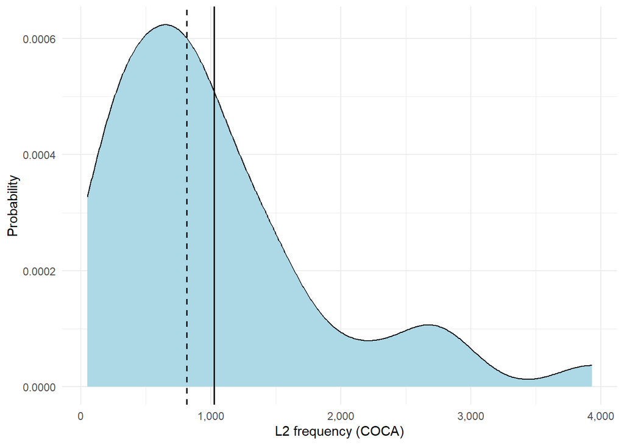

Figure 1: Distribution of L2 word frequencies used in the study

```r
ggplot(items, aes(x = L2Frequency)) +
  geom_density(fill = "lightblue") +
  geom_vline(xintercept = mean(items$L2Frequency), linewidth = 0.7) +
  geom_vline(xintercept = median(items$L2Frequency), linetype = "dashed", linewidth = 0.7) +
  scale_y_continuous(labels = scales::comma) +
  scale_x_continuous(labels = scales::comma) +
  labs(x = "L2 frequency (COCA)",
       y = "Probability") +
theme_minimal()
```

In Figure 1 we can clearly see a right-skewed distribution which we saw in the table with the positive skewness values (~1.51). As you may recall, a normally distributed graph would look like a symmetric bell curve. By contrast, here, we see that most words have lower or medium frequency with only a few really high-frequency words (see the long right tail). The mean sits to the right of the median which is another characteristic of positive skew. Our kurtosis value (~5.21) shows us the sharpness or peakedness of our curve which you can see quite nicely when you compare the graph for L2 frequency to the one for L1 frequency (see Figure 2).

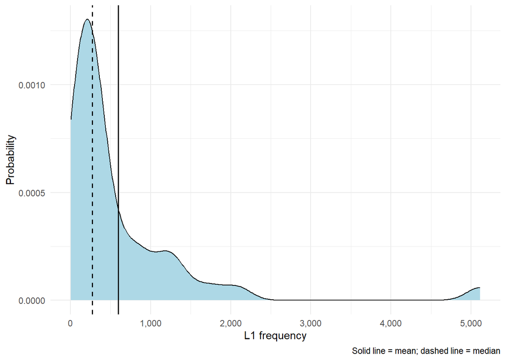

Figure 2: Distribution of L1 word frequencies used in the study

```r
ggplot(items, aes(x = L1Frequency)) +
  geom_density(fill = "lightblue") +
  geom_vline(xintercept = mean(items$L1Frequency), linewidth = 0.7) +
  geom_vline(xintercept = median(items$L1Frequency), linetype = "dashed", linewidth = 0.7) +
  scale_x_continuous(labels = scales::comma) +
  scale_y_continuous(labels = scales::comma) +
  labs(x = "L1 frequency",
       y = "Probability",
       caption = "Solid line = mean; dashed line = median") +
theme_minimal()
```

Figure 2 shows that a right-skew that is even stronger than for L2 word frequencies (skew ~3.59). This shows once again that most words are lower-frequency, there are only very few high-frequency words. Here, with a kurtosis value of ~18.10 we can see that with higher positive numbers the peak becomes sharper and sharper.

## 4.2 Descriptive statistics of the tests and reliability testing

In this section, we will attempt to reproduce the authors’ descriptive statistics regarding the two types of post-tests and calculate Cronbach’s α to estimate their reliability.

### 4.2.1 Reliability analysis

To conduct reliability analysis, the {psych} package needs to be installed and loaded.

```r
library(psych)
```

To calculate Cronbach’s α, Terai, Yamashita & Pasich (2021) applied the `alpha()` function to the vocabulary scores of both **the L1 and L2 production sets**. Below, we only show the code of the reliability analysis for Vocabulary A scores of the L1 production dataset, as an example:

```r
alpha(VocabularyA_L1production[,-1], warnings=FALSE)
```

**Show code for reliability analysis for the rest of the dataset**

```r
# Vocabulary A (L2 production)

alpha(VocabularyA_L2production[,-1], warnings = FALSE)

# Vocabulary B (L1 production)

alpha(VocabularyB_L1production[,-1], warnings = FALSE)

# Vocabulary B (L2 production)

alpha(VocabularyB_L2production[,-1], warnings = FALSE)
```

These reliability analyses compute Cronbach’s α, a measure of internal consistency of tests. This measure indicates whether responses are consistent across items. Before interpreting these results, we will get to the descriptive statistics of the two types of post-tests.

### 4.2.2 Accuracy

To investigate accuracy, Terai, Yamashita & Pasich (2021) processed the collected results for each participant — their ID, how many items they answered, and how many they got right — and visualized them in a boxplot. In the original code, the authors loaded the dataset for this section again and stored it under a different object name `dat.acc`. We skipped that step and simply used `dat` instead as it is already available as an `R` object in our local environment.

The following code chunk, which analyses data pertaining to L2 -> L1 direction of the L1 production set, processes the results for each participant — their ID, answered items, correct answers — and puts them into a clean table. Therefore, it gives us the core numbers necessary to describe and analyze learners’ vocabularly retrieval accuracy.

```r
# L2 → L1 (L1 production test)

z <- unique(dat$ID)

Score <- c()
IDes <- c()
try <- c()

for (i in z){
  dat |>
    dplyr::filter(ID == i, Condition == "L2L1", Test == "L1 Production") |>
    dplyr::select(Answer) -> acc_recT
  a <- as.vector(unlist(acc_recT))
  b <- sum(a)
  c <- length(a)
  Score <- c(Score, b)
  IDes <- c(IDes, i)
  try <- c(try, c)
}

accu_L2L1_L1Pro <- data.frame(IDes, try, Score)
names(accu_L2L1_L1Pro) <- c("ID", "Try", "Score")
accu_L2L1_L1Pro
```

We want to take the time to explain this code chunk in detail. The first line takes unique IDs from `dat` and saves it as `z`, `z` therefore being a vector of unique IDs. This part was slightly changed in comparison to Terai, Yamashita & Pasich (2021)’s code, which used three lines of code for this step. Further, a `for` loop is used to iterate over elements of this vector and assigning the IDs to the variable `i`. Inside this loop, for each `i` (a unique ID) the data is filtered for that participant under certain conditions, and then the Answer column is selected. The result is stored as the object `acc_recT`, which is further converted into a vector `a`. With `b` and `c`, the processed answers are computed and lastly, these results are appended into three vectors: `Score`, `IDes`, and `try`. These three vectors are combined into a final data frame `accu_L2L1_L1Pro`, where each vector becomes a column in a table, each row corresponding to one participant. These columns are renamed and the table is printed. If we want to properly see the table outside of the console, we can use the `View()` function:

```r
View(accu_L2L1_L1Pro)
```

For L1 -> L2 of the L1 production set, we follow the same steps.

**Show code for L1 -> L2 (L1 production test)**

```r
# L1 → L2 (L1 production test)

z <- unique(dat$ID)

Score <- c()
IDes <- c()
try <- c()
for (i in z){
  dat |>
    dplyr::filter(ID == i, Condition =="L1L2", Test == "L1 Production") |>
    dplyr::select(Answer)-> acc_recT
  a <- as.vector(unlist(acc_recT))
  b <- sum(a)
  c <- length(a)
  Score <- c(Score, b)
  IDes <- c(IDes, i)
  try <- c(try, c)
}

accu_L1L2_L1Pro <- data.frame(IDes, try, Score)
names(accu_L1L2_L1Pro) <- c("ID", "Try", "Score")
accu_L1L2_L1Pro
```

While accuracy did not play a very big role in Terai, Yamashita & Pasich (2021), the authors did a bit more with it in their code. Aside from using the `describe()` function on the final data frames, which returns a rich set of descriptive statistics, they visualized the results in a boxplot. Since we found them to be quite nice for understanding the descriptive statistics of the tests, we decided to include these in this chapter.

**Show use of `describe()` function on `Score` column to provide descriptive statistics for L1 production**

```r
# L2 → L1 learning
describe(accu_L2L1_L1Pro$Score)

# L1 → L2 learning
describe(accu_L1L2_L1Pro$Score)
```

To visualize descriptive statistics for the L1 production set, Terai, Yamashita & Pasich (2021) created a boxplot comparing the two learning directions. For this to work, the {beeswarm} package has to be installed and loaded. The authors assigned a data frame `L1pro` that contains the scores from both learning directions in the L1 production test. After changing the names of the columns to how they shall appear on the *x*-axis, the authors created a side-by-side boxplot for the two learning conditions. Finally, they added the `beeswarm()` function specifying `add = T`, which lets individual scores appear as jittered dots so that they don’t overlap.

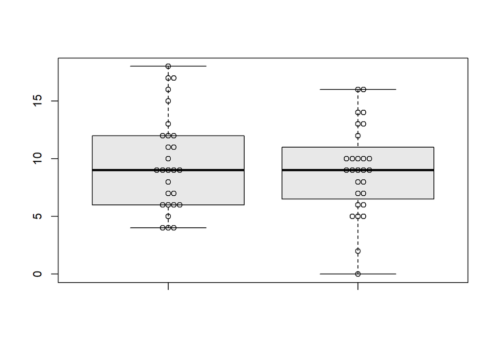

Figure 3: L1 Production Test scores across the two learning directions

```r
# Plot (L1 production)

library(beeswarm)

L1pro <- data.frame(accu_L2L1_L1Pro$Score, accu_L1L2_L1Pro$Score)
names(L1pro) <- c("L2 → L1 learning", "L1 → L2 learning")
boxplot(L1pro, col = "grey91", outline = T)
beeswarm(L1pro, add = T)
```

The same steps were applied to the L2 production set, using the L2 scores:

```r
# L2 → L1 (L2 production test)

z <- unique(dat$ID)

Score <- c()
IDes <- c()
try <- c()
for (i in z){
  dat |>
    dplyr::filter(ID == i, Condition == "L2L1", Test == "L2 Production") |>
    dplyr::select(Answer) -> acc_proT
  a <- as.vector(unlist(acc_proT))
  b <- sum(a)
  c <- length(a)
  Score <- c(Score, b)
  IDes <- c(IDes, i)
  try <- c(try, c)
}

accu_L2L1_L2Pro <- data.frame(IDes, try, Score)
names(accu_L2L1_L2Pro) <- c("ID", "Try", "Score")
accu_L2L1_L2Pro
```

**Show code for L1 → L2 (L2 production test)**

```r
# L1 → L2 (L2 production test)

z <- unique(dat$ID)

Score <- c()
IDes <- c()
try <- c()
for (i in z){
  dat |>
    dplyr::filter(ID == i, Condition == "L1L2", Test == "L2 Production") |>
    dplyr::select(Answer)-> acc_proT
  a <- as.vector(unlist(acc_proT))
  b <- sum(a)
  c <- length(a)
  Score <- c(Score, b)
  IDes <- c(IDes, i)
  try <- c(try, c)
}

accu_L1L2_L2Pro <- data.frame(IDes,try, Score)
names(accu_L1L2_L2Pro) <- c("ID", "Try", "Score")
accu_L1L2_L2Pro
```

**Show use of `describe()` function on `Score` column to provide descriptive statistics for L2 production**

```r
# L2 -> L1 learning

describe(accu_L2L1_L2Pro$Score)

# L1 -> L2 learning

describe(accu_L1L2_L2Pro$Score)
```

**As with L1,** Terai, Yamashita & Pasich (2021) created a similar boxplot comparing the two learning directions in L2 production using the beeswarm package.

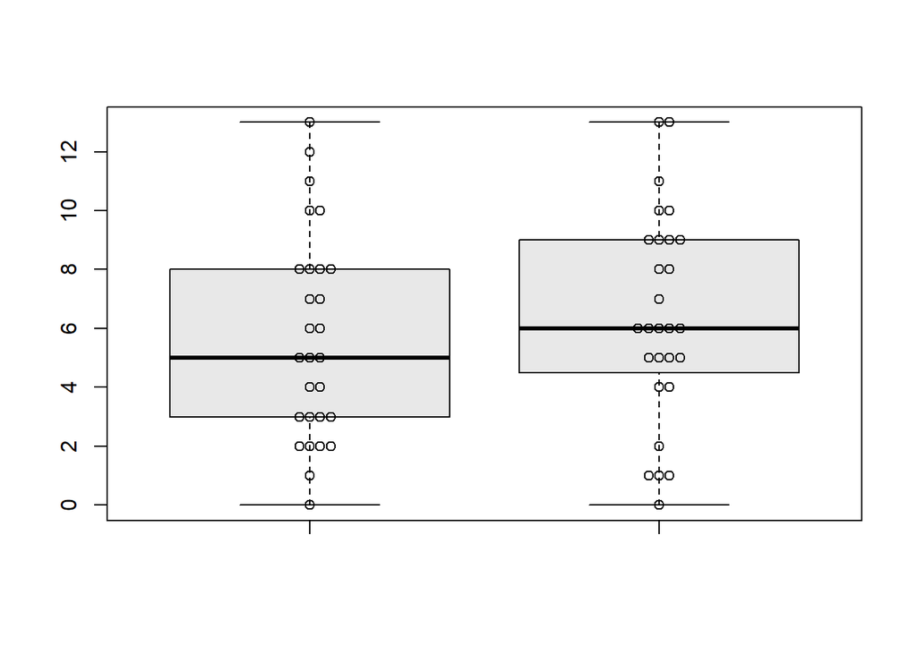

Figure 4: L2 Production Test scores across the two learning directions

```r
# Plot (L2 production)

L2pro <- data.frame(accu_L2L1_L2Pro$Score, accu_L1L2_L2Pro$Score)
names(L2pro) <- c("L2 → L1 learning", "L1 → L2 learning")
boxplot(L2pro, col = "grey91", outline = T)
beeswarm(L2pro, add = T)
```

Median scores in the L2 production test are similar for both learning directions (L2 → L1 and L1 → L2), suggesting comparable performance in both groups. L1 → L2 learning shows a slightly higher median. In the L2 → L1 group, values below the median are more spread out, indicating more variety. Comparing the L1 and L2 production tests, L1 production scores appear to be generally higher and more consistent across both learning directions.

### 4.2.3 Reproducing Table 4 and 5

After conducting reliability testing and descriptive statistics for the tests, we want to display the results in tables like Tables 4 and 5 from the original publication (Terai, Yamashita & Pasich 2021: 1126). As with the target items, there was no code accessible for creating the tables. But with the available data, we can find a way to reproduce them anyway!

First, we want to create a table that summarizes results of descriptive statistics of tests, similar to Table 4 (Terai, Yamashita & Pasich 2021: 1126). The {knitr} and {kableExtra} packages have to be loaded to proceed. As a first step, we assign a variable that contains the scores for both datasets (L1 and L2 production) and use the `describe()` function to get all the important measures.

```r
descriptive_stats_tests <- data.frame(L1pro, L2pro) |>
  describe()
```

To reproduce the original table, the first two columns (`vars` and `n`) are removed. Also, the rows are renamed to be more readable.

```r
descriptive_stats_tests_trimmed <- descriptive_stats_tests |>
  select(-n, -vars, -trimmed, -mad, -range, -se)

rownames(descriptive_stats_tests_trimmed) <- c("L2 → L1 (L1pro)", "L1 → L2 (L1pro)", "L2 → L1 (L2pro)", "L1 → L2 (L2pro)")
```

Now we want to display the results in a clean, formatted table using the `kable()` function.

```r
kable(descriptive_stats_tests_trimmed,
      digits = 2) |>
  pack_rows(index = c("L1 production test" = 2, "L2 production test" = 2)) |>
  kable_styling(full_width = FALSE, bootstrap_options = c("striped", "hover"))
```

Table 4: Descriptive Statistics for the L1 and L2 production test scores

|  | mean | sd | median | min | max | skew | kurtosis |
| --- | --- | --- | --- | --- | --- | --- | --- |
| **L1 production test** |  |  |  |  |  |  |  |
| L2 → L1 (L1pro) | 9.71 | 4.16 | 9 | 4 | 18 | 0.44 | -0.92 |
| L1 → L2 (L1pro) | 9.00 | 3.85 | 9 | 0 | 16 | -0.15 | -0.30 |
| **L2 production test** |  |  |  |  |  |  |  |
| L2 → L1 (L2pro) | 5.64 | 3.49 | 5 | 0 | 13 | 0.40 | -0.92 |
| L1 → L2 (L2pro) | 6.39 | 3.52 | 6 | 0 | 13 | -0.01 | -0.80 |

We have created Table 4, a table that summarizes the descriptive statistics of the two types of post-tests, where the measures of scores in the two production tests can be easily compared. In the L1 production test, scores were shown to be generally higher than in L2 production test.

```r
alpha_A_L1 <- alpha(VocabularyA_L1production[,-1], warnings = FALSE)
alpha_A_L2 <- alpha(VocabularyA_L2production[,-1], warnings = FALSE)
alpha_B_L1 <- alpha(VocabularyB_L1production[,-1], warnings = FALSE)
alpha_B_L2 <- alpha(VocabularyB_L2production[,-1], warnings = FALSE)
```

Then we use `sprintf()` to create a summary table showing the reliability estimates and 95% confidence intervals (CIs) for each test and level, and format strings for the table.

```r
alpha_table <- data.frame(
  Vocabulary = c("Vocabulary A", "Vocabulary B"),

  Alpha_L1 = c(
    sprintf("%.2f", alpha_A_L1$total$raw_alpha),
    sprintf("%.2f", alpha_B_L1$total$raw_alpha)
  ),
  CI_L1 = c(
    sprintf("[%.2f - %.2f]", alpha_A_L1$feldt$lower.ci, alpha_A_L1$feldt$upper.ci),
    sprintf("[%.2f - %.2f]", alpha_B_L1$feldt$lower.ci, alpha_B_L1$feldt$upper.ci)
  ),

  Alpha_L2 = c(
    sprintf("%.2f", alpha_A_L2$total$raw_alpha),
    sprintf("%.2f", alpha_B_L2$total$raw_alpha)
  ),
  CI_L2 = c(
    sprintf("[%.2f - %.2f]", alpha_A_L2$feldt$lower.ci, alpha_A_L2$feldt$upper.ci),
    sprintf("[%.2f - %.2f]", alpha_B_L2$feldt$lower.ci, alpha_B_L2$feldt$upper.ci)
  ),

  stringsAsFactors = FALSE
)
```

To rename the column headers, we use the `colnames()` function.

```r
# Rename column headers (use empty string for "Vocabulary")

colnames(alpha_table) <- c("", "Alpha", "95% CI", "Alpha", "95% CI")
```

Lastly, we want to display the results in a clean, formatted table similarly to the authors, for which we use the `kable()` function.

```r
alpha_table |>
  kable(align = "lcccc") %>%
  add_header_above(c(" " = 1, "L1 production" = 2, "L2 production" = 2))
```

Table 5: Alpha coefficients for L1 and L2 production test

|  | L1 production Alpha | L1 production 95% CI | L2 production Alpha | L2 production 95% CI |
| --- | --- | --- | --- | --- |
| Vocabulary A | 0.84 | [0.73 - 0.91] | 0.82 | [0.71 - 0.91] |
| Vocabulary B | 0.74 | [0.58 - 0.86] | 0.73 | [0.56 - 0.86] |

If we compare Table 5 about alpha coefficients with the one in the paper (Terai, Yamashita & Pasich 2021: 1126), we notice a difference in confidence intervals, specifically in the hundredths place. If we look at the output of `alpha()`, we see that it outputs out two kinds of confidence intervals: Feldt and Duhachek. Reading up in the help file of the `alpha()` function, it becomes clear that `alpha.ci` (used to access CIs from alpha function) finds CIs using the Feldt procedure, which is based on the mean covariance, while Duhachek procedure considers the variance of the covariances. In the help file it is stated that in March, 2022, `alpha.ci` was fixed to follow the Feldt procedure. Since the original publication was published in 2021, this might explain the deviating CIs here. If one would like to look at Duhachek’s CI instead, it can either be seen in the output of `alpha()`, or one might install an earlier version of the package. Since we want to use the current {psych} package for our project and the differences don’t change the main outcome, we decided to stick with Feldt’s CI and simply wanted to note why this difference occurs here.

As mentioned before, Cronbach’s alpha indicates whether responses are consistent between items, and ranges between 0 and 1, a higher value meaning higher reliability. As we can see in the results of the reliability analysis, alpha coefficients range from .73 to .84, showing adequate reliability for all the tests.

# 5 Generalized linear mixed-effects models

Terai, Yamashita & Pasich (2021) used generalized linear mixed-effect models (GLMMs), which are an extension of linear mixed models (see **?@sec-MLR**). GLMM analysis was employed to examine three predictor variables: Learning Condition (L2 to L1 and L1 to L2), Test Type (L1 production and L2 production), and Vocabulary Size (L2 Proficiency), as well as the interaction between two variables. They tried to predict Accuracy (the outcome variable) as a function of these predictor variables.

Three GLMMs were chosen for this analysis, the first to analyze the relationship between learning conditions and production tests (RQ1) (Terai, Yamashita & Pasich 2021: 1125). The second and third models analyze the effects of the two learning directions (L2 to L1 and L1 to L2) based on the results of the production tests (RQ2). They are pretty similar, except that the third and last model also make use of L2 production test scores. The first model (RQ 1) will be elaborated in more detail.

## 5.1 Effects of Learning Condition (RQ1)

As we recall from the introduction, the first research question of the study was: Which learning direction is more effective for vocabulary acquisition, L1 to L2 learning or L2 to L1 learning? Therefore, the first model was built to analyze the relationship between the outcomes of the production tests and the learning conditions. It contained Learning Condition and Test Type as predictor variables, as well as the interaction of the two variables. Random effects (Subject and Item) were included, and production test answers were used as the outcome variable (Terai, Yamashita & Pasich 2021: 1125).

Before getting started on the model, several packages have to be installed and loaded:

```r
library(lme4) # package for mixed models
library(effects) # package for plotting model effects
library(emmeans) # package for post-hoc comparisons
library(phia) # similar to {emmeans}
```

Also, the data needs to be set up for modeling. Following the code in Terai, Yamashita & Pasich (2021), the test type (`Test`) and the learning direction (`Condition`) variables are converted to factor variables as they represent categories rather than numerical values. Converting the variables into factors now will also be useful for the statistical analysis such as an ANOVA (Analysis of Variance), which will be conducted later.

```r
# Converting the categorical variables to factors using the function as.factor()
dat$Test <- as.factor(dat$Test)
dat$Condition <- as.factor(dat$Condition)
```

Before fitting the models, Terai, Yamashita & Pasich (2021) also apply **contrast coding**, also called **treatment coding** (Chambers & Hastie 1992). While it may look confusing and maybe intimidating, it is actually quite an important step. Basically, the study aims to compare two groups (L1 -> L2 vs. L2 -> L1). Terai, Yamashita & Pasich (2021) use **simple coding**, where the first Condition (L1 -> L2) gets coded as -0.5 and the second Condition (L2 -> L1) as +0.5. This makes interpretations easier when there are interactions since the intercept represents the overall mean across the two conditions (Barlaz 2022). Also, the `scale()` function is applied to the `Vocab` column to create a standardized version of the variable (by subtracting the mean and dividing by the standard deviation).

All these steps set up the dataset for modeling. Converting variables to factors and coding them with contrast ensures that they are interpreted correctly in the regression.

```r
c <- contr.treatment(2)
my.coding <- matrix(rep(1/2, 2, ncol = 1))
my.simple <- c-my.coding
my.simple
```

```
     2
1 -0.5
2  0.5
```

```r
contrasts(dat$Test) <- my.simple
contrasts(dat$Condition) <- my.simple

# Standardizing vocabulary scores (centered and scaled)
dat$s.vocab <- scale(dat$Vocab)
```

### 5.1.1 Model 1 without interaction

Terai, Yamashita & Pasich (2021) fit a logistic mixed-effects regression model predicting learners’ vocabulary production accuracy (`Answer`) as a function of `Test`, `Condition`, and their interaction with the `glmer()` function. We want to go through the process step-by-step, and connect the code with the interpretation of the model in the paper.

The following code chunk shows how Terai et al. fit the model without interaction `fit1`. Subsequently, the authors calculated the AIC (Akike Information Criterion) for their model. We will explain more about this criterion later.

```r
# Model without interaction
fit1 <- glmer(Answer ~ Test + Condition + (1|ID) + (1|ItemID),
              family = binomial,
              data = dat,
              glmerControl(optimizer = "bobyqa"))

# Produce result summary
summary(fit1)
```

```
Generalized linear mixed model fit by maximum likelihood (Laplace
  Approximation) [glmerMod]
 Family: binomial  ( logit )
Formula: Answer ~ Test + Condition + (1 | ID) + (1 | ItemID)
   Data: dat
Control: glmerControl(optimizer = "bobyqa")

      AIC       BIC    logLik -2*log(L)  df.resid
   2429.8    2458.1   -1209.9    2419.8      2145

Scaled residuals:
    Min      1Q  Median      3Q     Max
-3.4028 -0.6501 -0.3270  0.7222  5.6099

Random effects:
 Groups Name        Variance Std.Dev.
 ItemID (Intercept) 0.9467   0.9730
 ID     (Intercept) 0.8176   0.9042
Number of obs: 2150, groups:  ItemID, 40; ID, 28

Fixed effects:
            Estimate Std. Error z value Pr(>|z|)
(Intercept) -0.53260    0.23603  -2.257    0.024 *
Test2       -0.97215    0.10458  -9.296   <2e-16 ***
Condition2  -0.02364    0.10247  -0.231    0.818
---
Signif. codes:  0 '***' 0.001 '**' 0.01 '*' 0.05 '.' 0.1 ' ' 1

Correlation of Fixed Effects:
           (Intr) Test2
Test2      0.022
Condition2 0.002  0.003
```

```r
# Calculating AIC
AIC(fit1)
```

```
[1] 2429.771
```

Since it is so important for our study, we want to take a closer look at this step. Terai, Yamashita & Pasich (2021) fit a GLLM using the `glmer()` function. In the model formula, both fixed effects (Test answers and learning condition) and random effects (ID and ItemID) are specified. Specifying `(1 | ID)` allows for a random intercept for each level of the variable `ID` (participants) and `(1 | ItemID)` does the same for each level of the variable `ItemID` (test items). This accounts for repeated measures and inter-individual and inter-item variability. By specifying `family = binomial`, we can tell the `glmer()` function that the outcome variable is binary (correct answer = 1, incorrect answer = 0). The last argument specifies an optimizing algorithm, which helps the model to converge. The authors used the `summary()` function to examine the output of the model.

Without the interaction, the model assumes that the effects of `Test` and `Condition` are additive and do not depend on each other in any way. The AIC is a measure used to estimate the fit of a model to the data in comparison to another one, with a lower AIC indicating better fit. Therefore, we will get back to this after fitting the model with interaction to compare the performance of the two models.

If we look at the output of the model `summary()`, it includes *scaled residuals*. Residuals are the differences between observed and predicted values (see **?@sec-MLR**). This section shows summary statistics of the model’s residuals after scaling: Minimum, first quartile (25<sup>th</sup> percentile), median (50<sup>th</sup> percentile), third quartile (75<sup>th</sup> percentile), and maximum. These values give an impression of how well the model fits the data. The *Random effects* section computes the estimated variability in the intercept across subjects (ID) and items (ItemID), accounting for differences in overall accuracy between participants and between items.

### 5.1.2 Model 1 with interaction

Next, the authors fit a model similar to the first one, except that it also models a potential interaction between `Test` and `Condition`, thus investigating if the effect of one predictor variable depends on the level of the other.

For this model `fit1.1`, the `glmer()` function was used as well, but with a change in the formula: the predictors are connected with `*` instead of `+`. In addition to the model’s coefficient estimates and the AIC, Terai, Yamashita & Pasich (2021) also calculated confidence intervals for the model using the function `confint()`.

```r
# Model with interaction
fit1.1 <- glmer(Answer ~ Test * Condition + (1|ID) + (1|ItemID),
                family = binomial,
                data = dat,
                glmerControl(optimizer = "bobyqa"))
summary(fit1.1)
```

```
Generalized linear mixed model fit by maximum likelihood (Laplace
  Approximation) [glmerMod]
 Family: binomial  ( logit )
Formula: Answer ~ Test * Condition + (1 | ID) + (1 | ItemID)
   Data: dat
Control: glmerControl(optimizer = "bobyqa")

      AIC       BIC    logLik -2*log(L)  df.resid
   2427.1    2461.1   -1207.6    2415.1      2144

Scaled residuals:
    Min      1Q  Median      3Q     Max
-3.2386 -0.6340 -0.3341  0.7195  5.3153

Random effects:
 Groups Name        Variance Std.Dev.
 ItemID (Intercept) 0.9518   0.9756
 ID     (Intercept) 0.8222   0.9067
Number of obs: 2150, groups:  ItemID, 40; ID, 28

Fixed effects:
                 Estimate Std. Error z value Pr(>|z|)
(Intercept)      -0.53392    0.23667  -2.256   0.0241 *
Test2            -0.97597    0.10477  -9.315   <2e-16 ***
Condition2       -0.03763    0.10283  -0.366   0.7144
Test2:Condition2 -0.44597    0.20557  -2.169   0.0300 *
---
Signif. codes:  0 '***' 0.001 '**' 0.01 '*' 0.05 '.' 0.1 ' ' 1

Correlation of Fixed Effects:
            (Intr) Test2 Cndtn2
Test2       0.022
Condition2  0.005  0.019
Tst2:Cndtn2 0.005  0.029 0.063
```

```r
# Computing confidence intervals
confint(fit1.1)
```

```
Computing profile confidence intervals ...
```

```
                      2.5 %      97.5 %
.sig01            0.7629507  1.27445594
.sig02            0.6849006  1.24190402
(Intercept)      -1.0087438 -0.06326544
Test2            -1.1843879 -0.77093946
Condition2       -0.2405335  0.16501237
Test2:Condition2 -0.8521078 -0.04121349
```

```r
# Setting number of digits and calculating AIC
AIC(fit1.1)
```

```
[1] 2427.102
```

Now after calculating AICs for both versions of the model, it becomes apparent that the model *with* interaction has a lower AIC (with interaction: 2427.102; without interaction: 2429.771), indicating that the model fits the data better.

The authors state that the results show a significant main effect of **Test Type** (Estimate = -0.976, SE = 0.105, z = -9.315, p < .001) (Terai, Yamashita & Pasich 2021: 1126). We want to find these results in the output of our code. When we look at the summary output of `fit1.1` under Fixed effects, the numbers can be found in the “Test2” row. They are all rounded up to three digits for better readability. The negative estimate tells us that accuracy in Test 2 is predicted to be lower than in Test 1. The *p*-value can be extracted from the column marked Pr(>|z|), where it is displayed in the form of <2e-16, since it is such a small number. It tells us that the effect (of switching between test types) is significant. The *z*-value tells us how many standard deviations away a value is from the mean.

Moving on to **Learning Condition**, the authors found no statistically significant main effect: Condition2: Estimate = -0.038, SE = 0.103, z = -0.366, p = .714) (Terai, Yamashita & Pasich 2021: 1126). In this case, the *p*-value is > 0.05, meaning that the effect of learning condition is *not* significantly different from no effect. The main effect estimate of Condition2 is quite small (close to 0), telling us the predicted odds don’t change much when moving from one learning condition to the other. However, the **interaction** of Test Type and Learning Condition (see row “Test2:Condition2”) was shown to be significant (Estimate = -0.446, SE = 0.206, z = -2.169, p = .030) (Terai, Yamashita & Pasich 2021: 1126). The interaction term suggests that the effect of `Test` on accuracy depends on the `Condition`, or the other way around. The estimate tells us that, when participants take the L2 production test after learning in the L2 -> L1 direction, **the accuracy is even lower than when only one of them is**. The *p*-value of .030 indicates that this observed interaction effect is unlikely to have occurred due to chance only.

### 5.1.3 Model comparison

Terai, Yamashita & Pasich (2021) conducted further analysis and comparisons of the two models, using the function `anova()`, which is an analysis of variance (a statistical method which compares the variance across the means of different groups), and `testInteractions()`, which makes it possible to perform simple main effects analysis. First, the authors conducted a comparison of the models with and without the interaction term using the `anova()` function.

```r
anova(fit1, fit1.1)
```

```
Data: dat
Models:
fit1: Answer ~ Test + Condition + (1 | ID) + (1 | ItemID)
fit1.1: Answer ~ Test * Condition + (1 | ID) + (1 | ItemID)
       npar    AIC    BIC  logLik -2*log(L) Chisq Df Pr(>Chisq)
fit1      5 2429.8 2458.1 -1209.9    2419.8
fit1.1    6 2427.1 2461.1 -1207.5    2415.1 4.669  1    0.03071 *
---
Signif. codes:  0 '***' 0.001 '**' 0.01 '*' 0.05 '.' 0.1 ' ' 1
```

Terai, Yamashita & Pasich (2021) compared the two models with the `anova()` function to test if the interaction term improved the model. The test outputs a *p*-value of 0.03071. Being smaller than 0.05, the effect is statistically significant, which is also symbolized by the * specified in the significance codes in the output. It tells us that `fit1.1` (model with interaction) fits the data significantly better than `fit1` (without interaction).

### 5.1.4 Pairwise comparisons on the effects of `Condition` and `Test`

After comparing the models and testing the interaction, Terai, Yamashita & Pasich (2021) conducted pairwise comparisons on the effects of `Condition` and `Test`.

For this, the authors used the `emmeans()` function, which computes estimated marginal means. First, they conducted pairwise comparisons of Condition levels within each level of Test, and assigned it to a variable `a`. This object is then printed.

```r
# Computing estimated marginal means using the `emmeans()` function

a <- emmeans(fit1.1, pairwise ~ Condition|Test, adjust = "tukey")
a
```

```
$emmeans
Test = L1 Production:
 Condition  emmean    SE  df asymp.LCL asymp.UCL
 L1L2      -0.1386 0.251 Inf    -0.631     0.354
 L2L1       0.0467 0.251 Inf    -0.446     0.540

Test = L2 Production:
 Condition  emmean    SE  df asymp.LCL asymp.UCL
 L1L2      -0.8916 0.254 Inf    -1.389    -0.394
 L2L1      -1.1522 0.256 Inf    -1.654    -0.651

Results are given on the logit (not the response) scale.
Confidence level used: 0.95

$contrasts
Test = L1 Production:
 contrast    estimate    SE  df z.ratio p.value
 L1L2 - L2L1   -0.185 0.141 Inf  -1.317  0.1878

Test = L2 Production:
 contrast    estimate    SE  df z.ratio p.value
 L1L2 - L2L1    0.261 0.150 Inf   1.738  0.0821

Results are given on the log odds ratio (not the response) scale.
```

Additionally, Terai, Yamashita & Pasich (2021) calculated confidence intervals and effect sizes for this object `a`.

```r
# Computing confidence intervals for emmeans object a

confint(a, parm, level = 0.95)
```

```
$emmeans
Test = L1 Production:
 Condition  emmean    SE  df asymp.LCL asymp.UCL
 L1L2      -0.1386 0.251 Inf    -0.631     0.354
 L2L1       0.0467 0.251 Inf    -0.446     0.540

Test = L2 Production:
 Condition  emmean    SE  df asymp.LCL asymp.UCL
 L1L2      -0.8916 0.254 Inf    -1.389    -0.394
 L2L1      -1.1522 0.256 Inf    -1.654    -0.651

Results are given on the logit (not the response) scale.
Confidence level used: 0.95

$contrasts
Test = L1 Production:
 contrast    estimate    SE  df asymp.LCL asymp.UCL
 L1L2 - L2L1   -0.185 0.141 Inf   -0.4612    0.0905

Test = L2 Production:
 contrast    estimate    SE  df asymp.LCL asymp.UCL
 L1L2 - L2L1    0.261 0.150 Inf   -0.0332    0.5544

Results are given on the log odds ratio (not the response) scale.
Confidence level used: 0.95
```

```r
# Calculating effect sizes

eff_size(a, sigma = sigma(fit1.1), edf = Inf)
```

```
Since 'object' is a list, we are using the contrasts already present.
```

```
Test = L1 Production:
 contrast      effect.size    SE  df asymp.LCL asymp.UCL
 (L1L2 - L2L1)      -0.185 0.141 Inf   -0.4612    0.0905

Test = L2 Production:
 contrast      effect.size    SE  df asymp.LCL asymp.UCL
 (L1L2 - L2L1)       0.261 0.150 Inf   -0.0332    0.5544

sigma used for effect sizes: 1
Confidence level used: 0.95
```

The same procedure was applied in the other direction: While with variable `a`, `emmeans()` was told to do pairwise comparisons of Condition levels within each level of Test, Terai, Yamashita & Pasich (2021) also computed all comparisons of Test levels within each level of Condition, and saved this object as the variable `b`.

```r
# Computing EMMs

b <- emmeans(fit1.1, pairwise ~ Test|Condition, adjust = "tukey")
b
```

```
$emmeans
Condition = L1L2:
 Test           emmean    SE  df asymp.LCL asymp.UCL
 L1 Production -0.1386 0.251 Inf    -0.631     0.354
 L2 Production -0.8916 0.254 Inf    -1.389    -0.394

Condition = L2L1:
 Test           emmean    SE  df asymp.LCL asymp.UCL
 L1 Production  0.0467 0.251 Inf    -0.446     0.540
 L2 Production -1.1522 0.256 Inf    -1.654    -0.651

Results are given on the logit (not the response) scale.
Confidence level used: 0.95

$contrasts
Condition = L1L2:
 contrast                      estimate    SE  df z.ratio p.value
 L1 Production - L2 Production    0.753 0.145 Inf   5.206  <.0001

Condition = L2L1:
 contrast                      estimate    SE  df z.ratio p.value
 L1 Production - L2 Production    1.199 0.149 Inf   8.054  <.0001

Results are given on the log odds ratio (not the response) scale.
```

```r
# Computing confidence intervals for emmeans object b

confint(b, parm, level = 0.95)
```

```
$emmeans
Condition = L1L2:
 Test           emmean    SE  df asymp.LCL asymp.UCL
 L1 Production -0.1386 0.251 Inf    -0.631     0.354
 L2 Production -0.8916 0.254 Inf    -1.389    -0.394

Condition = L2L1:
 Test           emmean    SE  df asymp.LCL asymp.UCL
 L1 Production  0.0467 0.251 Inf    -0.446     0.540
 L2 Production -1.1522 0.256 Inf    -1.654    -0.651

Results are given on the logit (not the response) scale.
Confidence level used: 0.95

$contrasts
Condition = L1L2:
 contrast                      estimate    SE  df asymp.LCL asymp.UCL
 L1 Production - L2 Production    0.753 0.145 Inf     0.469      1.04

Condition = L2L1:
 contrast                      estimate    SE  df asymp.LCL asymp.UCL
 L1 Production - L2 Production    1.199 0.149 Inf     0.907      1.49

Results are given on the log odds ratio (not the response) scale.
Confidence level used: 0.95
```

```r
# Calculating effect sizes

eff_size(b, sigma = sigma(fit1.1), edf = Inf)
```

```
Since 'object' is a list, we are using the contrasts already present.
```

```
Condition = L1L2:
 contrast                        effect.size    SE  df asymp.LCL asymp.UCL
 (L1 Production - L2 Production)       0.753 0.145 Inf     0.469      1.04

Condition = L2L1:
 contrast                        effect.size    SE  df asymp.LCL asymp.UCL
 (L1 Production - L2 Production)       1.199 0.149 Inf     0.907      1.49

sigma used for effect sizes: 1
Confidence level used: 0.95
```

The analysis conducted in the code chunk above provides the most important information for the interpretation of this model as reported in Terai, Yamashita & Pasich (2021). We want to go through the authors’ statements and connect them with the code we reproduced. In the paper, the authors claim there was a statistically significant difference between the scores of the two tests, suggesting that L1 production test scores were higher than L2 production test scores in both learning conditions (**L2 to L1 learning:** *p* < .001, *d* = 1.20, 95% CI [0.91, 1.49]; **L1 to L2 learning:** *p* < .001, *d* = 0.75, [0.47, 1.04]) (Terai, Yamashita & Pasich 2021: 1126). Now, we want to take a close look at these numbers and what they mean. We can find the numbers stated here in the object `b` output by the `emmeans()` function. The *p*-values show up when printing `b`, and lie < .001 for both learning conditions. A small *p*-value tells us that an effect is unlikely due to chance, but does not inform us about how large the effect is. This is where effect size comes into play: The function `eff_size()` computes the estimated effect sizes for both conditions, which are referred to as *d* in the paper. They both demonstrate a large (larger for L2 to L1) effect size, and indicate that the difference (different levels of `Test` within each `Condition`) is not just statistically significant, but also sizeable. Lastly, the `confint()` function applied to `b` computes the 95% confidence intervals for both learning directions, which means that, if the study were to be repeated many times, in 95% of the repetitions, the 95% confidence interval would contain the true standardized effect size.

The authors also mention that results showed no main effects of **Learning Condition** (L1 production test: *p* = .188, *d* = -0.19, 95% CI [-0.46, 0.09]; L2 production test: *p* = .082, *d* = 0.26, [-0.03, 0.55]) (Terai, Yamashita & Pasich 2021: 1126). This can be derived when we look at object `a`, which compares learning conditions separately for L1 Production and L2 Production. Printing `a` shows *p*-values, which lie above 0.05 in both production tests and indicate no statistical significance of the differences between learning conditions. The effect sizes show a small negative effect for L1 Production, and a small positive effect for L2 Production. The confidence intervals in both cases include 0 (since it lies between -0.03 and 0.55, for example), telling us that no effect (*d* = 0) is a possibility given the data. To sum up, all these values do *not* support a main effect of Learning Condition, as the authors make clear in their paper.

### 5.1.5 Visualizing Model 1

Finally, the authors presented the results of this model in a plot that visualizes all important information regarding research question 1 (Terai, Yamashita & Pasich 2021: 1127). In the following code chunk, you can see how they set graphical parameters and then created a base `R` plot.

```r
# Setting graphical parameters for the plot

par(pty = "s") # sets the shape: square
par(pin =c(10, 10)) # sets the plot size
par("ps") # font size
```

```
[1] 12
```

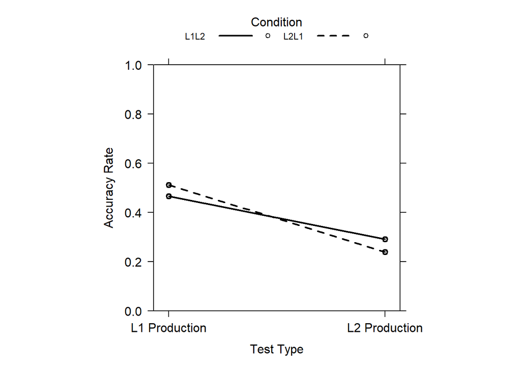

Figure 5: Interaction between Test Type and Learning Condition on accuracy rates

```r
# Plot

plot(allEffects(fit1.1), multiline = T, ci.style = "bands", xlab = "Test Type", ylab = "Accuracy Rate",
       main = "", lty = c(1,2), rescale.axis = F, ylim = c(0, 1),
       colors = "black", asp = 1)
```

Figure 5 shows the interaction between Test Type and Learning Condition on accuracy rates, based on the generalized linear mixed-effects model (`fit1.1`). It is an effect plot generated with the `allEffects()` function. The solid line represents the L1 to L2 learning condition; the dotted line represents the L2 to L1 learning condition. The *y*-axis represents accuracy rates on both the L1 and L2 production tests. The *x*-axis represents the two test types. We can see that the accuracy rates differ across Test Types and Learning Conditions, with a clear interaction between the two: The non-parallel lines indicate that the effect of one variable changes depends on the level of the other variable. The distance between the two lines is relatively small at each test type, which reflects the results that revealed no significant difference in learning effects between L2 to L1 learning and L1 to L2 learning.

Generally, Terai, Yamashita & Pasich (2021) used base `R` plots in their original code. While there is nothing wrong with that, one could also use {ggplot2}, which provides many options to customise the plot. Also, it makes it easy to see what is plotted and how specific elements are modified, which contributes to the reproducibility of the code. If you want to learn more about using {ggplot2}, check out **?@sec-DataViz**.